# Ryu et al EHP 2024 Summary Statistics

Min Hyung Ryu

08 April, 2024

# Purpose

Purpose of this html document is to summarize dataset analyzed in Ryu et al EHP 2024 manuscript.

Please consider citing our manuscript when using our dataset. Most up-to-date citation recommendation and data use will be posted on our GitHub page.

Our GitHub repository is https://github.com/COERDUBC/Ryu_EHP_Letter_2024

For any issue regarding code and data, please post issues to our GitHub page. For any other inquiry, please contact the corresponding author, Dr. Chris Carlsten.

# Manuscript

**Relationship between airway microbiome and the immune response to diesel exhaust: a randomized crossover controlled exposure study**

Min Hyung Ryu<sup>1,2,3</sup>, Illiassou Hamidou Soumana<sup>1,2</sup>, Denise J Wooding<sup>1,2</sup>, Fernando Sergio Leitao Filho<sup>3</sup>, Julia Yang<sup>3</sup>, Corey Nislow<sup>4</sup>, Christopher F Rider<sup>1,2</sup>, Janice M Leung<sup>3</sup>, Chris Carlsten<sup>1,2,3</sup>

<sup>1</sup> Air Pollution Exposure Lab, Division of Respiratory Medicine, <sup>2</sup> Centre for Lung Health, Vancouver Coastal Health Research Institute, <sup>3</sup> Heart and Lung Innovation, St. Paul’s Hospital, <sup>4</sup> Department of Biochemistry and Molecular Biology, University of British Columbia, Vancouver, BC, Canada

**Correspondence to be addressed to:**  
Chris Carlsten, MD, MPH

2775 Laurel St. 7<sup>th</sup> Floor, The Lung Center, Vancouver General Hospital – Gordon and Leslie Diamond Health Care Centre, Vancouver, BC V5Z 1M9

E-mail: carlsten@mail.ubc.ca

Telephone: 1-604-875-4729

**Funding:** This study was supported by a research grant from the Canadian Respiratory Research Network.

# Data

```r
Demographics <- readRDS(paste0(data_path, "/COPA_EHP_Demographics_Public.rds"))
Microbiome <- readRDS(paste0(data_path, "/COPA_EHP_Microbiome_Public.rds"))
colnames(Microbiome)[3] <- "ASV"
Cytokines <- readRDS(paste0(data_path, "/COPA_EHP_VPlex_BAL_Public.rds"))
LODs <- readRDS(paste0(data_path, "/COPA_EHP_VPlex_BAL_LODs_Public.rds"))
colnames(LODs) <- c("Target","LLOD")
Spiro <- readRDS(paste0(data_path, "/COPA_EHP_Spiro_Public.rds"))
```

## Demographic data

Below we show demographic variables for each subject

```r
DT::datatable(Demographics)
```

|  | EHP_sid | Age | Group | PackYear | TimeSinceQuit | FEV1_FVC | FEV1pp |
| --- | --- | --- | --- | --- | --- | --- | --- |
| 1 | EHP01 | 47 | NS | 0 | N/A | 80 | 118 |
| 2 | EHP02 | 51 | NS | 0 | N/A | 77 | 106 |
| 3 | EHP03 | 72 | NS | 0 | N/A | 80 | 162 |
| 4 | EHP04 | 54 | NS | 0 | N/A | 79 | 120 |
| 5 | EHP05 | 55 | NS | 0 | N/A | 74 | 111 |
| 6 | EHP06 | 52 | NS | 0 | N/A | 80 | 120 |
| 7 | EHP07 | 63 | NS | 0 | N/A | 78 | 127 |
| 8 | EHP08 | 58 | NS | 0 | N/A | 75 | 133 |
| 9 | EHP09 | 56 | ES | 50 | 8 | 74 | 113 |
| 10 | EHP10 | 50 | ES | 15 | 16 | 79 | 106 |

[output cut: 15 more lines]

## Microbiome data

Below we show searchable data table for microbiome data

```r
DT::datatable(Microbiome)
```

|  | EHP_sid | shannon | ASV | faith_pd | pielou_e | DNAConc (ng/ul) | Concentration (copies/uL) | 16S (copies/ng) |
| --- | --- | --- | --- | --- | --- | --- | --- | --- |
| 1 | EHP01 | 5.096197514163505 | 67 | 7.474487099499999 | 0.8484524214980935 | 53.3 | 613.5 | 25.5931175015 |
| 2 | EHP02 | 5.19380423269127 | 93 | 8.952750163500001 | 0.8008718493734994 | 8.5 | 233.85 | 20.377576552 |
| 3 | EHP09 | 5.3728592007833 | 102.5 | 9.079002800999998 | 0.804294327210523 | 11.05 | 164.85 | 11.62012987015 |
| 4 | EHP16 | 4.518017409614655 | 92 | 7.953364385999999 | 0.692955051301122 | 21 | 755.5 | 49.044205495 |
| 5 | EHP03 | 4.726342207683395 | 79 | 7.2492904215 | 0.7495617320783985 | 7.125 | 16.5 | 2.4722222225 |
| 6 | EHP17 | 5.098429703179165 | 116.5 | 9.7620963395 | 0.7427532618919344 | 9.600000000000001 | 628 | 63.245614035 |
| 7 | EHP10 | 4.352531200959925 | 52 | 5.183501954 | 0.819362610390479 | 19.375 | 552.8 | 19.433963553 |
| 8 | EHP04 | 4.871794624165934 | 131.5 | 10.8816657485 | 0.6933494235642156 | 11.075 | 170.95 | 13.1561435065 |
| 9 | EHP11 | 4.735863370275855 | 113 | 10.454083232 | 0.6944538345008975 | 6.4 | 108.85 | 18.2440432325 |
| 10 | EHP18 | 4.612758929210219 | 57.5 | 5.962960738 | 0.7895156206653104 | 5.649999999999999 | 5.2 | 0.9182439331000001 |

[output cut: 15 more lines]

## Cytokines

Here, we replace 1/2 LOD values with NA. Then we show summary statistics for the entire dataset for cytokine measurements.

```r
# place NA into values that were converted to 1/2 LOD
df <- Cytokines
var_names <- colnames(df)[4:ncol(df)]
df <- df %>% pivot_longer(
  cols = all_of(var_names)
)
colnames(df)[4] <- "Target"
df <- merge(df, LODs)
df$value[which(df$value < df$LLOD)] = NA
colnames(df)[5] <- "concentration"
df <- df %>% select(!all_of("LLOD"))
df <- df %>% pivot_wider(
  names_from = Target,
  values_from = concentration
)
summary(df)
```

```
##    EHP_sid          Exposure    Sample              GM-CSF
##  Length:50          FA:25    Length:50          Min.   :0.09742
##  Class :character   DE:25    Class :character   1st Qu.:0.26278
##  Mode  :character            Mode  :character   Median :0.41169
##                                                 Mean   :0.50818
##                                                 3rd Qu.:0.62953
##                                                 Max.   :2.64131
##                                                 NA's   :5
##  IL-12/IL-23p40        IL-15            IL-16             IL-1α
##  Min.   : 0.1758   Min.   :0.1221   Min.   :  1.171   Min.   :0.3758
##  1st Qu.: 1.4935   1st Qu.:0.7486   1st Qu.: 14.138   1st Qu.:0.5798
##  Median : 3.7244   Median :1.0633   Median : 23.888   Median :0.8864
##  Mean   : 4.5928   Mean   :1.4453   Mean   : 36.760   Mean   :1.0180
##  3rd Qu.: 6.7054   3rd Qu.:1.8999   3rd Qu.: 37.339   3rd Qu.:1.2420
##  Max.   :19.4461   Max.   :6.1194   Max.   :282.943   Max.   :3.1112
##  NA's   :3         NA's   :2                          NA's   :19
##       IL-6              IL-7             IL-8            IP-10
##  Min.   : 0.1524   Min.   :0.1193   Min.   :  4.58   Min.   :  3.476
##  1st Qu.: 0.6860   1st Qu.:0.2378   1st Qu.: 12.26   1st Qu.: 21.178
##  Median : 0.9831   Median :0.3333   Median : 21.14   Median : 48.953
##  Mean   : 1.6647   Mean   :0.4866   Mean   : 38.86   Mean   : 91.278
##  3rd Qu.: 1.3856   3rd Qu.:0.4822   3rd Qu.: 30.68   3rd Qu.:117.376
##  Max.   :18.1315   Max.   :5.1954   Max.   :441.82   Max.   :649.923
##  NA's   :2         NA's   :9
##      MCP-1               MDC             MIP-1β            TARC
##  Min.   :  0.9127   Min.   : 6.877   Min.   : 2.014   Min.   : 0.7788
##  1st Qu.: 12.1269   1st Qu.:12.326   1st Qu.: 4.825   1st Qu.: 2.0110
##  Median : 20.4420   Median :26.164   Median : 6.414   Median : 4.2307
##  Mean   : 39.9960   Mean   :29.623   Mean   : 8.659   Mean   : 5.8404
##  3rd Qu.: 31.0466   3rd Qu.:43.752   3rd Qu.: 9.327   3rd Qu.: 9.4182
##  Max.   :413.6537   Max.   :71.000   Max.   :44.973   Max.   :19.6242
##                     NA's   :21       NA's   :2        NA's   :4
##       VEGF
##  Min.   :  4.901
##  1st Qu.: 72.594
##  Median : 98.695
##  Mean   :121.862
##  3rd Qu.:161.382
##  Max.   :447.272
##
```

Concentrations are in pg/mL.

## Lung Function

The following is data table for spirometry values measured before FA or DE exposure (“baseline”) in all participants included in our analysis. The value in time column refers to time with respect to the end of 2 hour exposure session. Therefore, Time == -4h was considered as the baseline for each study visit. In the dataset, time == 0h and time == 24h are immediately and 24 hours after the end of exposure.

```r
Spiro_baseline <- Spiro %>% subset(Time == "-4h")
DT::datatable(Spiro_baseline)
```

|  | EHP_sid | Exposure | Time | FVC | FEV1 | FEV1/FVC | FEF25-75 | PEFR | FVC %Pred | FEV1 %Pred | FEV1/FVC %Pred | FEF25-75 %Pred | PEFR %Pred |
| --- | --- | --- | --- | --- | --- | --- | --- | --- | --- | --- | --- | --- | --- |
| 2 | EHP01 | DE | -4h | 4.01 | 3.22 | 0.8 | 3.02 | 7.28 | 110.16 | 111.81 | 101.27 | 103.07 | 104.3 |
| 7 | EHP01 | FA | -4h | 4.32 | 3.39 | 0.79 | 3.11 | 7.28 | 118.68 | 117.71 | 100 | 106.14 | 104.3 |
| 18 | EHP02 | DE | -4h | 5.11 | 3.65 | 0.71 | 2.46 | 10.22 | 130.69 | 112.65 | 85.54 | 68.91 | 113.94 |
| 22 | EHP02 | FA | -4h | 5.26 | 3.78 | 0.72 | 2.61 | 10.59 | 134.53 | 116.67 | 86.75 | 73.11 | 118.06 |
| 26 | EHP09 | FA | -4h | 4.17 | 3.04 | 0.73 | 2.07 | 10.72 | 106.38 | 100.33 | 96.05 | 78.11 | 130.1 |
| 32 | EHP09 | DE | -4h | 3.93 | 2.91 | 0.74 | 2.11 | 10.7 | 100.26 | 96.04 | 97.37 | 79.62 | 129.85 |
| 41 | EHP16 | DE | -4h | 4.59 | 2.83 | 0.62 | 1.19 | 6.37 | 118.6 | 105.99 | 84.93 | 62.63 | 90.35 |
| 44 | EHP16 | FA | -4h | 4.49 | 2.9 | 0.65 | 1.47 | 7.44 | 116.02 | 108.61 | 89.04 | 77.37 | 105.53 |
| 48 | EHP03 | DE | -4h | 3.55 | 2.85 | 0.8 | 3 | 5.49 | 122.84 | 139.71 | 111.11 | 171.43 | 102.23 |
| 50 | EHP03 | FA | -4h | 3.49 | 2.79 | 0.8 | 2.94 | 5.61 | 120.76 | 136.76 | 111.11 | 168 | 104.47 |

[output cut: 40 more lines]

# Summary Tables

## Demographic and microbiome

Below we show summarized demographic variable and microbiome stratified by study groups.

```r
knitr::kable(table_1, format = "markdown", digits = 2)
```

|  | ES | ES-COPD | NS |
| --- | --- | --- | --- |
| n | 7 | 10 | 8 |
| Age (mean (SD)) | 59.71 (10.16) | 69.30 (4.79) | 56.50 (7.87) |
| PackYear (mean (SD)) | 47.86 (33.09) | 24.65 (22.69) | 0.00 (0.00) |
| TimeSinceQuit (mean (SD)) | 16.12 (14.47) | 21.80 (13.16) | NaN (NA) |
| FEV1_FVC (mean (SD)) | 76.86 (5.55) | 58.00 (9.33) | 77.88 (2.36) |
| FEV1pp (mean (SD)) | 106.53 (9.23) | 91.02 (13.82) | 124.62 (17.29) |
| shannon (median [IQR]) | 4.74 [4.53, 5.14] | 4.74 [4.54, 5.04] | 5.15 [4.91, 5.32] |
| ASV (median [IQR]) | 67.50 [55.50, 99.50] | 72.50 [62.38, 83.88] | 95.75 [85.75, 123.75] |
| faith_pd (median [IQR]) | 6.75 [6.05, 9.02] | 7.56 [7.04, 8.18] | 9.15 [8.03, 10.75] |
| pielou_e (median [IQR]) | 0.80 [0.74, 0.81] | 0.75 [0.74, 0.82] | 0.78 [0.75, 0.81] |

## Cytokines

### FA exposure

Below is the summary table for cytokines measured after FA exposure.

```r
knitr::kable(table_2, format = "markdown", digits = 2)
```

|  | ES | ES-COPD | NS |
| --- | --- | --- | --- |
| n | 7 | 10 | 8 |
| GM-CSF (median [IQR]) | 0.37 [0.37, 0.78] | 0.26 [0.23, 0.61] | 0.45 [0.33, 0.58] |
| IL-1α (median [IQR]) | 0.30 [0.18, 0.63] | 1.24 [0.96, 1.43] | 0.57 [0.18, 0.73] |
| IL-6 (median [IQR]) | 1.05 [0.62, 1.22] | 1.02 [0.46, 1.74] | 1.04 [0.84, 1.21] |
| IL-7 (median [IQR]) | 0.23 [0.16, 0.31] | 0.20 [0.06, 0.32] | 0.36 [0.21, 0.49] |
| IL-8 (median [IQR]) | 20.48 [13.87, 21.86] | 20.25 [13.12, 54.50] | 22.36 [11.62, 27.15] |
| IL-12/IL-23p40 (median [IQR]) | 2.29 [1.52, 5.75] | 3.48 [0.62, 3.97] | 4.88 [2.64, 6.29] |
| IL-15 (median [IQR]) | 1.84 [1.27, 2.20] | 0.71 [0.51, 0.83] | 1.03 [0.85, 2.39] |
| IL-16 (median [IQR]) | 20.29 [16.72, 21.81] | 32.95 [9.28, 47.85] | 30.38 [17.96, 45.62] |
| IP-10 (median [IQR]) | 54.89 [25.12, 85.37] | 38.63 [21.95, 63.43] | 50.41 [30.73, 89.30] |
| MCP-1 (median [IQR]) | 15.63 [13.45, 31.25] | 25.33 [11.94, 67.00] | 18.74 [13.37, 23.07] |
| MDC (median [IQR]) | 3.08 [2.84, 11.96] | 6.50 [2.84, 13.84] | 21.01 [2.84, 48.84] |
| MIP-1β (median [IQR]) | 6.10 [4.94, 7.39] | 5.08 [3.30, 12.26] | 7.31 [6.55, 9.39] |
| TARC (median [IQR]) | 3.31 [2.45, 5.18] | 3.75 [1.32, 4.94] | 5.49 [1.97, 11.46] |
| VEGF (median [IQR]) | 92.47 [80.86, 123.30] | 90.80 [35.55, 166.37] | 104.70 [75.38, 223.82] |

Concentrations are in pg/mL.

### DE exposure

Below is the summary table for cytokines measured after DE exposure.

```r
knitr::kable(table_3, format = "markdown", digits = 2)
```

|  | ES | ES-COPD | NS |
| --- | --- | --- | --- |
| n | 7 | 10 | 8 |
| GM-CSF (median [IQR]) | 0.49 [0.40, 0.58] | 0.33 [0.13, 0.61] | 0.36 [0.25, 0.44] |
| IL-1α (median [IQR]) | 0.38 [0.23, 0.89] | 0.66 [0.34, 0.89] | 0.28 [0.18, 0.44] |
| IL-6 (median [IQR]) | 0.88 [0.71, 1.22] | 1.33 [0.66, 2.26] | 0.82 [0.69, 1.20] |
| IL-7 (median [IQR]) | 0.24 [0.16, 0.40] | 0.35 [0.16, 0.55] | 0.34 [0.29, 0.46] |
| IL-8 (median [IQR]) | 12.15 [10.84, 18.22] | 25.43 [19.89, 33.87] | 23.90 [13.53, 34.09] |
| IL-12/IL-23p40 (median [IQR]) | 5.57 [1.66, 6.39] | 3.36 [1.48, 7.00] | 2.42 [1.35, 4.80] |
| IL-15 (median [IQR]) | 1.66 [1.09, 2.94] | 0.73 [0.52, 0.93] | 1.23 [1.09, 1.51] |
| IL-16 (median [IQR]) | 20.40 [15.84, 23.39] | 32.79 [14.50, 38.03] | 20.14 [13.35, 27.88] |
| IP-10 (median [IQR]) | 61.00 [21.43, 185.40] | 59.19 [31.73, 151.85] | 25.15 [17.06, 83.35] |
| MCP-1 (median [IQR]) | 22.79 [16.02, 27.29] | 22.28 [15.17, 55.43] | 16.48 [13.37, 24.80] |
| MDC (median [IQR]) | 7.34 [5.03, 18.14] | 21.14 [3.08, 41.19] | 24.28 [2.84, 32.79] |
| MIP-1β (median [IQR]) | 5.13 [4.13, 6.98] | 8.82 [6.01, 10.45] | 5.51 [4.83, 6.60] |
| TARC (median [IQR]) | 4.34 [2.17, 7.23] | 3.09 [1.39, 9.56] | 4.18 [2.05, 8.45] |
| VEGF (median [IQR]) | 134.86 [100.41, 141.48] | 96.64 [80.03, 121.35] | 137.10 [48.99, 188.35] |

Concentrations are in pg/mL.

## Lung Function

### Baseline: before exposure

Summary of lung function measured at study visit baseline stratified by group and exposure.

```r
knitr::kable(table_4, format = "markdown", digits = 2)
```

|  | ES_FA | ES_DE | ES-COPD_FA | ES-COPD_DE | NS_FA | NS_DE |
| --- | --- | --- | --- | --- | --- | --- |
| n | 7 | 7 | 10 | 10 | 8 | 8 |
| FVC (median [IQR]) | 3.63 [3.44, 4.36] | 3.73 [3.50, 4.22] | 3.18 [2.68, 3.70] | 3.22 [2.62, 4.02] | 4.70 [3.86, 5.19] | 4.91 [3.89, 5.13] |
| FEV1 (median [IQR]) | 2.97 [2.87, 3.24] | 2.92 [2.86, 3.24] | 1.88 [1.60, 2.52] | 1.86 [1.71, 2.59] | 3.39 [2.97, 3.82] | 3.66 [3.13, 4.08] |
| FEV1/FVC (median [IQR]) | 0.76 [0.75, 0.82] | 0.76 [0.74, 0.80] | 0.60 [0.54, 0.65] | 0.61 [0.55, 0.68] | 0.77 [0.73, 0.79] | 0.80 [0.77, 0.80] |
| FEF25-75 (median [IQR]) | 3.09 [2.38, 3.30] | 3.06 [2.42, 3.20] | 0.96 [0.73, 1.29] | 0.99 [0.71, 1.20] | 2.78 [2.44, 3.17] | 3.16 [2.87, 3.87] |
| PEFR (median [IQR]) | 9.03 [7.65, 10.49] | 7.22 [6.44, 10.52] | 5.28 [4.17, 6.50] | 5.35 [4.43, 6.22] | 8.27 [5.89, 10.90] | 8.42 [6.97, 10.34] |
| FVC %Pred (median [IQR]) | 87.11 [84.93, 96.22] | 88.81 [86.18, 93.65] | 92.65 [84.49, 99.54] | 89.58 [83.54, 100.01] | 112.94 [108.45, 119.20] | 112.22 [110.11, 117.99] |
| FEV1 %Pred (median [IQR]) | 95.19 [91.56, 100.28] | 92.41 [90.30, 96.90] | 76.82 [63.77, 86.92] | 79.22 [63.64, 89.02] | 112.41 [102.36, 116.93] | 113.59 [111.10, 121.07] |
| FEV1/FVC %Pred (median [IQR]) | 100.00 [96.82, 109.33] | 98.65 [97.40, 107.33] | 81.75 [75.17, 88.15] | 83.00 [74.58, 91.00] | 100.65 [92.86, 101.97] | 103.30 [99.67, 105.86] |
| FEF25-75 %Pred (median [IQR]) | 89.56 [83.13, 126.51] | 90.24 [79.87, 126.97] | 47.53 [35.45, 57.93] | 55.57 [35.85, 61.75] | 100.71 [82.26, 110.82] | 122.28 [96.61, 140.59] |
| PEFR %Pred (median [IQR]) | 97.28 [87.86, 118.18] | 84.56 [71.13, 117.78] | 74.22 [53.27, 100.50] | 74.45 [58.81, 91.19] | 107.89 [102.98, 119.24] | 107.98 [101.72, 114.15] |

### 0h: Immediately after each exposure

Summary of lung function measured immediately after each exposure stratified by group and exposure.

```r
knitr::kable(table_5, format = "markdown", digits = 2)
```

|  | ES_FA | ES_DE | ES-COPD_FA | ES-COPD_DE | NS_FA | NS_DE |
| --- | --- | --- | --- | --- | --- | --- |
| n | 7 | 7 | 10 | 10 | 8 | 7 |
| FVC (median [IQR]) | 3.78 [3.59, 4.34] | 3.75 [3.54, 4.27] | 3.06 [2.62, 3.78] | 3.13 [2.82, 4.08] | 4.96 [4.48, 5.05] | 4.75 [3.86, 5.16] |
| FEV1 (median [IQR]) | 3.00 [2.76, 3.34] | 2.96 [2.82, 3.41] | 1.82 [1.67, 2.65] | 1.93 [1.70, 2.58] | 3.84 [3.54, 3.90] | 3.63 [3.01, 3.84] |
| FEV1/FVC (median [IQR]) | 0.76 [0.76, 0.78] | 0.77 [0.74, 0.81] | 0.61 [0.58, 0.66] | 0.62 [0.54, 0.66] | 0.78 [0.76, 0.80] | 0.77 [0.74, 0.78] |
| FEF25-75 (median [IQR]) | 2.53 [2.42, 2.90] | 2.92 [2.62, 2.98] | 1.10 [0.78, 1.21] | 1.16 [0.73, 1.36] | 3.34 [2.92, 3.49] | 2.77 [2.46, 3.28] |
| PEFR (median [IQR]) | 8.36 [5.91, 10.06] | 7.42 [6.48, 10.23] | 4.78 [3.85, 5.32] | 4.72 [3.24, 5.38] | 8.41 [6.44, 10.61] | 9.78 [7.53, 10.09] |
| FVC %Pred (median [IQR]) | 90.79 [89.76, 92.67] | 89.47 [87.00, 94.75] | 89.22 [79.48, 98.48] | 87.80 [81.70, 97.66] | 112.22 [110.10, 129.29] | 111.69 [109.52, 121.85] |
| FEV1 %Pred (median [IQR]) | 92.67 [91.64, 98.62] | 95.25 [92.06, 97.94] | 76.83 [66.12, 86.71] | 76.47 [67.45, 86.50] | 116.69 [110.91, 126.39] | 112.04 [105.14, 116.32] |
| FEV1/FVC %Pred (median [IQR]) | 100.00 [98.65, 103.39] | 101.32 [98.01, 110.20] | 83.00 [79.31, 88.19] | 83.69 [74.24, 88.19] | 100.65 [97.76, 104.96] | 100.00 [96.16, 101.98] |
| FEF25-75 %Pred (median [IQR]) | 95.09 [87.81, 103.25] | 90.57 [85.08, 127.46] | 52.12 [43.25, 58.50] | 57.11 [36.78, 62.06] | 115.96 [87.45, 130.79] | 96.28 [81.66, 119.28] |
| PEFR %Pred (median [IQR]) | 77.67 [72.46, 111.49] | 97.14 [67.05, 116.03] | 65.55 [51.36, 80.59] | 63.34 [54.74, 82.52] | 114.15 [94.62, 118.13] | 113.04 [109.79, 117.98] |

### 24h: 24 hours after each exposure

Summary of lung function measured 24 hours after each exposure stratified by group and exposure.

```r
knitr::kable(table_6, format = "markdown", digits = 2)
```

|  | ES_FA | ES_DE | ES-COPD_FA | ES-COPD_DE | NS_FA | NS_DE |
| --- | --- | --- | --- | --- | --- | --- |
| n | 7 | 7 | 10 | 10 | 7 | 8 |
| FVC (median [IQR]) | 3.71 [3.52, 4.30] | 3.79 [3.41, 4.24] | 3.24 [2.66, 3.98] | 3.20 [2.74, 3.93] | 4.59 [4.04, 5.18] | 4.78 [3.96, 5.22] |
| FEV1 (median [IQR]) | 2.98 [2.68, 3.26] | 2.93 [2.69, 3.44] | 1.88 [1.58, 2.57] | 1.81 [1.71, 2.47] | 3.48 [3.20, 3.80] | 3.57 [3.18, 4.08] |
| FEV1/FVC (median [IQR]) | 0.74 [0.73, 0.78] | 0.79 [0.74, 0.82] | 0.59 [0.56, 0.63] | 0.61 [0.52, 0.66] | 0.76 [0.75, 0.78] | 0.78 [0.77, 0.80] |
| FEF25-75 (median [IQR]) | 2.91 [1.98, 3.22] | 3.01 [2.44, 3.33] | 0.90 [0.75, 1.25] | 0.92 [0.69, 1.37] | 3.13 [2.59, 3.17] | 3.18 [2.71, 3.60] |
| PEFR (median [IQR]) | 8.75 [6.40, 10.32] | 7.76 [7.09, 10.47] | 5.52 [4.08, 6.31] | 4.60 [4.04, 5.78] | 9.76 [6.44, 11.13] | 8.62 [7.10, 9.83] |
| FVC %Pred (median [IQR]) | 91.13 [87.02, 95.06] | 91.19 [84.13, 95.22] | 92.50 [87.46, 100.46] | 86.18 [85.18, 98.93] | 108.65 [103.23, 120.57] | 111.60 [109.25, 122.25] |
| FEV1 %Pred (median [IQR]) | 92.99 [90.84, 96.56] | 93.53 [91.26, 96.90] | 79.94 [66.57, 83.98] | 75.86 [64.74, 85.32] | 112.26 [104.00, 114.07] | 113.46 [108.00, 120.55] |
| FEV1/FVC %Pred (median [IQR]) | 98.72 [96.67, 103.34] | 101.32 [99.29, 110.00] | 80.26 [75.53, 84.96] | 82.72 [71.84, 87.33] | 98.70 [97.42, 103.34] | 101.91 [100.33, 105.64] |
| FEF25-75 %Pred (median [IQR]) | 85.85 [82.80, 105.04] | 98.25 [83.93, 120.75] | 50.45 [33.16, 54.60] | 51.29 [33.74, 58.87] | 106.77 [84.66, 117.32] | 110.63 [99.20, 136.53] |
| PEFR %Pred (median [IQR]) | 92.93 [73.69, 114.84] | 91.45 [78.00, 117.22] | 72.85 [55.06, 96.53] | 70.58 [54.61, 88.07] | 118.18 [106.58, 122.54] | 109.09 [102.74, 116.69] |

# Plots

## Boxplots of microbiome data

Group comparisons

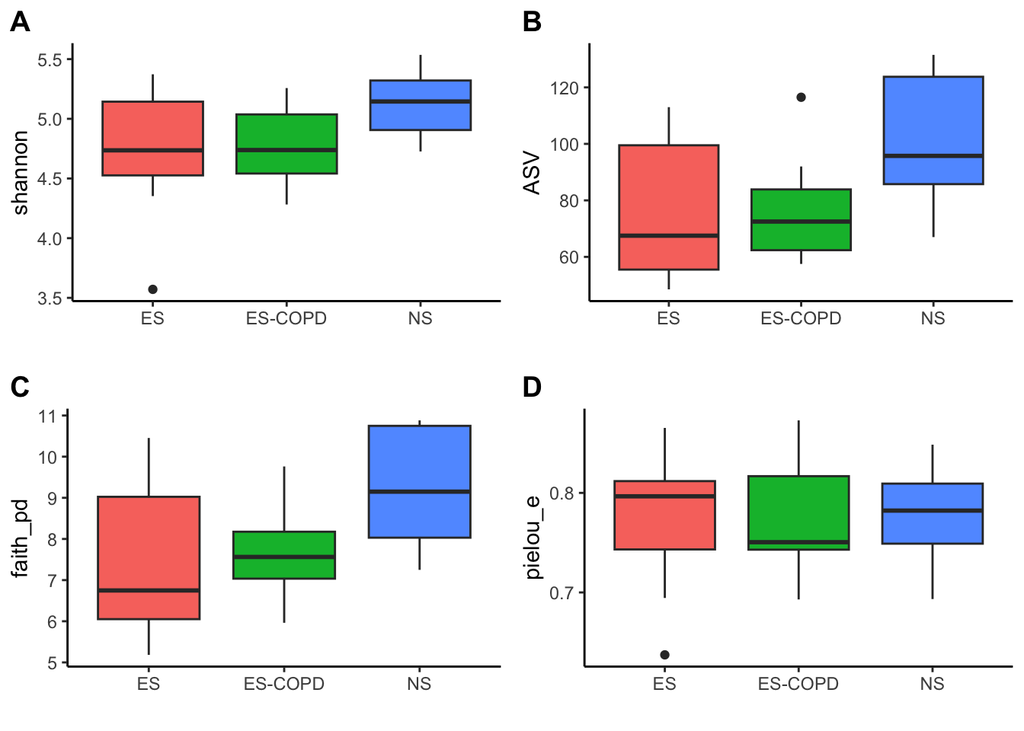

```r
data <- merge(Demographics, Microbiome)
plot1 <- data %>%
  ggplot(aes(x=Group, y=shannon, fill=Group)) +
    geom_boxplot() +
    theme_classic() +
    theme(
      legend.position="none",
      plot.title = element_text(size=11)
    ) +
    ggtitle("") +
    xlab("")

plot2 <- data %>%
  ggplot(aes(x=Group, y=ASV, fill=Group)) +
    geom_boxplot() +
    theme_classic() +
    theme(
      legend.position="none",
      plot.title = element_text(size=11)
    ) +
    ggtitle("") +
    xlab("")

plot3 <- data %>%
  ggplot(aes(x=Group, y=faith_pd, fill=Group)) +
    geom_boxplot() +
    theme_classic() +
    theme(
      legend.position="none",
      plot.title = element_text(size=11)
    ) +
    ggtitle("") +
    xlab("")

plot4 <- data %>%
  ggplot(aes(x=Group, y=pielou_e, fill=Group)) +
    geom_boxplot() +
    theme_classic() +
    theme(
      legend.position="none",
      plot.title = element_text(size=11)
    ) +
    ggtitle("") +
    xlab("")

ggarrange(plot1, plot2, plot3, plot4,
          labels = c("A", "B", "C", "D"),
          ncol = 2, nrow = 2)
```

ASV = amplicon sequence variant. Faith_pd = Faith’s phylogenetic diversity. Pielou_e = Pielou’s evenness. Airway microbiome metrics were obtained by averaging values from two bronchial brushes that were collected on two different occasions in each participant after each exposure.